# Midterm Instructions

## Introduction

### Policies

- You may use: any online resources, including anything posted on Canvas.
- You may NOT contact anyone, inside or outside this class, during the course of the exam. This includes email, chat/messenger services, and posting on online forums and message boards.
- You may NOT use exam materials from previous years.
- Violations of academic honesty include accessing and using any illegal materials, and giving or receiving help on this exam including looking at other student’s exams, allowing other students to look at your own exam, and/or revealing any information about this exam or future exams to someone who has not yet taken it.
- Students who exhibit academic misconduct will be reported to the Office of Student Rights and Responsibilities; academic dishonesty may be punishable by a grade of F in this course.
- You may **not** discuss the exam with any other students until after the exams have been returned to all students.
- If you witness others exhibiting academic misconduct, you have a duty to report them to your professor.

### Instructions

- Please note that you will need to use the data documentation in order to successfully complete this exam.
- The problems on this exam do not necessarily need to be completed sequentially, e.g., if you cannot accomplish problem 1, you may still be able to accomplish problem 2.
- Some parts to problems may need to be completed sequentially. If you cannot complete part (a), please outline code or your thought process for completing part (b).
- All questions should be answered **using R code**. Make sure your code prints out only the information that directly answers the question. **Penalties will be given if your `.html` file has extra output beyond that which answers the question.**
- If your code has errors that you cannot fix in time, you may also include in the comments explanations of your thought process, to potentially receive partial credit.
- Submit both your `.Rmd` and `.html` files on Canvas by the end of the allotted time. However, only your `.html` file will be graded - make sure the knitted output contains all your answers.

### The Dataset

Parts Three and Four of this exam pertain to the dataset `min_wage.csv` on Canvas.

Documentation for this dataset can be found [here](https://github.com/Lislejoem/Minimum-Wage-by-State-1968-to-2017/tree/master). (Note that you can also find the code that the author used to clean the data. It **is** permissible to look at this code, but do not copy-paste from that source.)

## Part One: General R Questions [50 points]

**Fill out your answers in the Part One Quiz on Canvas.**

1. In Week 1, you were asked to consider the relationship between private companies and open-source community. In a short paragraph (3-5 sentences), share your thoughts on this topic as it relates to R, RStudio, and the R community.
2. Suppose I create an object with the following:

```r
a <- 10
```

Which of the following is an accurate statement about `a`?

*Check all that apply*

1. `a` is an atomic vector.
2. `a` is a numeric vector.
3. `a` has the object class `integer`.
4. `length(a)` is equal to `1`.
5. `a + c(1,4,7)` will give an error.
6. `as.character(a)` will return `"10"`
3. Consider the following output:

```r
str(mystery_object)
```

```
##  num [1:3, 1:4] 0.417 -0.621 -0.901 0.531 2.658 ...
```

What object structure is `mystery_object`?

*Check all that apply*

1. An atomic vector
2. A vector
3. A matrix
4. A data frame
5. A list
4. Suppose `student_names` is a **character vector** containing the names of students in a particular class. For example, one entry of `student names` might be `Brad Pitt`, and another might be `Jeffrey Armstrong`. You may assume there are no middle names or two-word first or last names.

Which of the following will return the *full names* of students whose *first name* starts with a K?

*Check all that apply*

1. `str_extract(student_names, "^K")`
2. `str_extract(student_names, "^K.*")`
3. `str_extract(student_names, "^K[a-z]*")`
4. `str_extract(student_names, "K[a-z]* ")`
5. `str_subset(student_names, "^K")`
6. `str_subset(student_names, "^K.*")`
7. `str_subset(student_names, "^K[a-z]*")`
8. `str_subset(student_names, "K[a-z]* ")`
5. Consider the following function:

```r
vectorify <- function(x) {

  if (length(x) == 1) {

    x <- rep(x, 10)

  } else {

    #???????

  }

  return(x)

}
```

What would be the most reasonable code to put in the `#??????` part?

1. `return(x)`
2. `return(x[1:10])`
3. `return("x must be length 1")`
4. `print("x must be length 1")`
5. `stop("x must be length 1")`
6. `length(x) <- 1`
7. `x <- x + 1:10`

## Part Two: Write Functions [100 points]

**Please submit your .Rmd and .html for this section to Canvas** *Please only use the default R Markdown format for this section.*

Consider the following example vector, consisting of numbers and also “footnotes” of letters in parentheses.

```r
vec <- c("1.01 - 1.02 (b)", "4.24 - 6.7 (c,b)", "1.5 (a) - 2.4 (d-f)")
```

Suppose we would like to process this vector into three separate vectors: the first number, the second number, and the footnotes.

1. Write a function called `get_footnotes` that returns the footnotes as a list of string vectors, for example:

```r
get_footnotes(vec)
```

```
## [[1]]
## [1] "(b)"
##
## [[2]]
## [1] "(c,b)"
##
## [[3]]
## [1] "(a)"   "(d-f)"
```

2. Write a function called `get_nums` that returns the first and last numbers as a data frame, for example:

```r
get_nums(vec)
```

```
## # A tibble: 3 x 2
##   First.Num Last.Num
##       <dbl>    <dbl>
## 1      1.01     1.02
## 2      4.24     6.7
## 3      1.5      2.4
```

## Part Three: Short Answer [100 points]

**Please submit your .Rmd and .html for this section to Canvas** *Please only use the default R Markdown format for this section.*

For all questions, please show your work in code.

1. How many entries in this dataset had footnote `(b)`?
2. Which states had the highest and lowest minimum wage in each year? (Use the `High.Value` dollar amount, not adjusted for inflation.)
3. Which states had the largest change in minimum wage (difference between high and low values) in each year?
4. Consider only Texas and California. Make a plot comparing their minimum wage in 2018 dollars (`Low.2018`) over time:

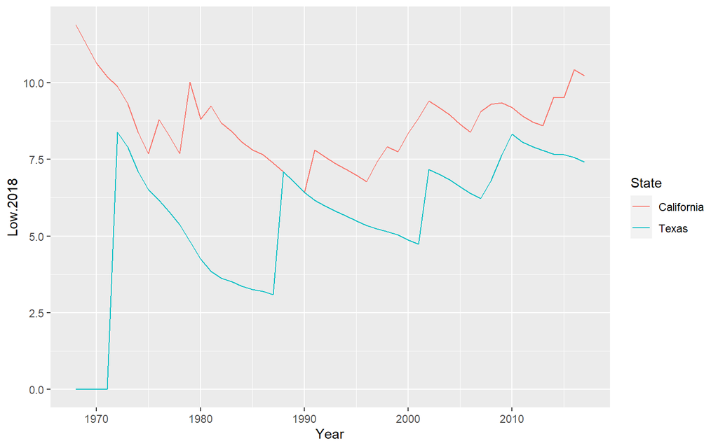

5. Create a new data frame with the following properties:
- Each row should represent a different year of observations.
- Each column should represent one state
- Values should be the highest minimum wage (`High.2018`) in that state for a particular year

## Part Four: Open-Ended Analysis [150 points]

**Please submit your .Rmd and .html for this section to Canvas** *In this section, you **may** use any formatting options you wish.*

### How does minimum wage differ by region?

Decide on your own regional grouping for the states. For example, you might consider East vs. West, North vs. South, or something more nuanced. You are welcome to reference any internet source to determine your grouping.

Compare the minimum wage between regions to come up with an interesting insight.  
For example: Did some regions grow faster than others? Do some regions tend to have higher minimum wage than others? etc.

Create a writeup of approximately 1 page (including all plots and tables) that tells a clear story. Your writeup must include at least on plot and at least one summary statistic.